# Chapter 1: Introduction and examples

Jesse Mu

September 7, 2016

# Introduction

*Bayesian inference*: the process of learning by updating prior probabilistic beliefs in light of new information. Data analysis tools built on these foundations are known as *Bayesian methods*.

## The Bayesian learning framework

We want to estimate a parameter $\theta \in \Theta$ from a dataset $y \in \mathcal{Y}$.

- $p(\theta)$, defined for all $\theta \in \Theta$, is our prior distribution about the space of possible parameters
- Bayesian methods require a **sampling model**: $P(y \mid \theta)$ describes the probability that of a specific dataset given a parameter.
  - Note that later, this will be useful for prediction!

Then we wish to update our belief distribution about $\theta$ given. The *posterior distribution* is defined as

$$\begin{align}
p(\theta \mid y) = \frac{p(y \mid \theta) p(\theta)}{\int_{\Theta}p(y \mid \tilde{\theta}) p(\tilde{\theta}) \; d\tilde{\theta}}.
\end{align}$$

Note that the denominator is constant and doesn’t need to be computed, since we can just normalize our posterior distribution such that $P(\theta \mid y)$ for all $\Theta$ sums up to 1. Thus we commonly write

$$\begin{align}
p(\theta \mid y) \propto p(y \mid \theta) p(\theta).
\end{align}$$

### versus frequentist learning

(from [Resnik & Hardisty, “Gibbs Sampling for the Uninitiated”](https://www.umiacs.umd.edu/~resnik/pubs/LAMP-TR-153.pdf))

The difference between Bayesian learning and frequentist learning is the consideration of *prior beliefs* about parameters. In standard Maximum Likelihood Estimation (MLE), we select the parameter that is most likely to have generated the observed data:

$$\theta_{ML} = \underset{\theta}{\text{argmax}} \; p(y \mid \theta).$$

Using Bayesian Maximum A Posteriori Estimation, however, we select $\theta$ that is most likely given the observed data. The difference is that our measure of “likelihood given the data” is influenced by our prior beliefs about $\theta$, as in Equation 2:

$$\begin{align}
\theta_{MAP} &= \underset{\theta}{\text{argmax}} \; p(\theta \mid y) \\
&= \underset{\theta}{\text{argmax}} p(y \mid \theta) p(\theta).
\end{align}$$

Note that with an uninformative prior $\theta \sim \text{Uniform}$, the MAP estimate is the same as the ML estimate.

# Why Bayes?

## As an approach to probability and statistics

The debate between Bayesians and frequentists dives into some very philosophical issues. Cox’s theorem (1946, 1961) gives a formal proof for thinking about probabilities using a Bayesian approach. I will likely want to look at an explanation of these proofs later: http://ksvanhorn.com/bayes/Papers/rcox.pdf

Outside of formal mathematical grounding, Bayesian methods have excellent practical benefits as data analysis tools:

1. Even if prior probabilities are not exactly quantifiable, approximations of $p(\theta)$ and $p(\theta \mid y)$ are still useful for analyzing how rational learners would change beliefs
2. Bayesian methods can represent principled ways of doing analysis when there are no alternative methods

## As models of cognition

An appeal of Bayesian learning is that it is also cognitively intuitive. Humans have beliefs about the world, whose uncertainty can be expressed probabilistically. Then, given data, these beliefs are rationally updated. There is a rich tradition in modeling human cognition using Bayesian methods to great success, with plenty of work done in showing how people’s beliefs and knowledge about the world can be expressed probabilistically (e.g. [Griffiths & Tenenbaum, 2006](http://web.mit.edu/cocosci/Papers/Griffiths-Tenenbaum-PsychSci06.pdf))

Bayesianism is not without its detractors, however. Some critics argue that the evidence that Bayesian analysis is weak, and that sufficiently sophisticated models are unfalsifiable. See [Bowers & Davis (2012)](http://psycnet.apa.org/journals/bul/138/3/389/), comment by [Griffiths, Chater, Norris, Pouget (2012)](http://cocosci.berkeley.edu/tom/papers/LabPublications/HowBayesiansGetBeliefs.pdf), reply by [Bowers & Davis (2012)](http://www.ncbi.nlm.nih.gov/pubmed/22545688).

# Example 1: Estimating the probability of a rare event

We are interested in the prevelance of a disease in a city. Let $\theta \in [0, 1]$ be the fraction of infected individuals. We take a sample of 20 individuals and record the number of individuals $y \in Y = {0, 1, \dots, 20}$ with the disease.

The sampling model is

$$Y \mid \theta \sim \text{Binomial}(20, \theta),$$

i.e. each individual has an independent $\theta$% chance of having the disease.

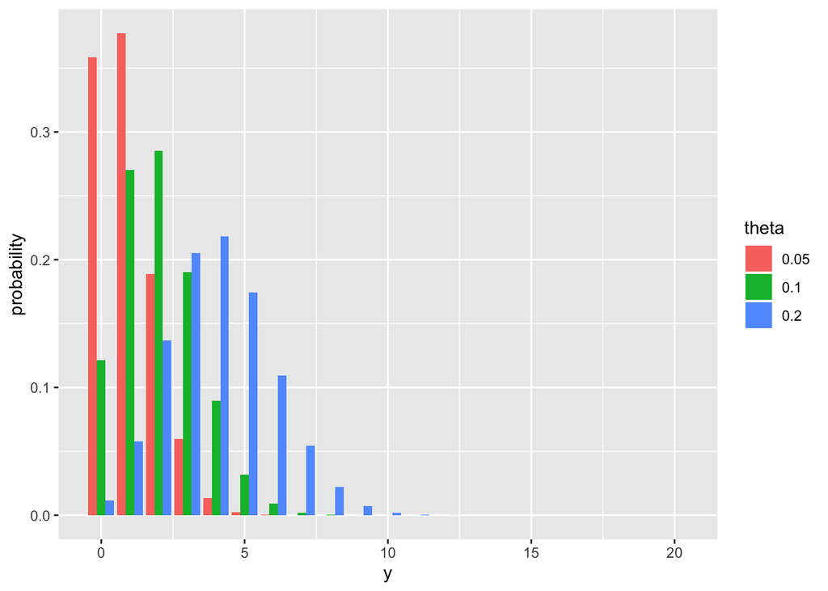

For various theta, the probability of observing y infected individuals in the sample.

```r
d = data.frame(
  y = 0:20,
  theta = factor(rep(c(0.05, 0.10, 0.20), each = 21)),
  probability = c(dbinom(0:20, 20, 0.05), dbinom(0:20, 20, 0.1), dbinom(0:20, 20, 0.2))
)
ggplot(d, aes(x = y, y = probability, fill = theta)) +
  geom_bar(stat = "identity", position = "dodge")
```

Imagine we believe $\theta$ is probably in the interval $[0.05, 0.20]$. For computational convenience, we will encode this prior as a Beta distribution

$$\theta \sim \text{Beta}(2, 20)$$

Conveniently, (we will prove this later), given $Y \mid \theta \sim \text{Binomial}(n, \theta)$ and $\theta \sim \text{Beta}(a, b)$,

$$(\theta \mid Y = y) \sim \text{Beta}(a + y, b + n - y).$$

For example, if we observe 0/20 individuals infected, $\theta \mid {Y = 0} \sim \text{Beta}(2, 40)$.

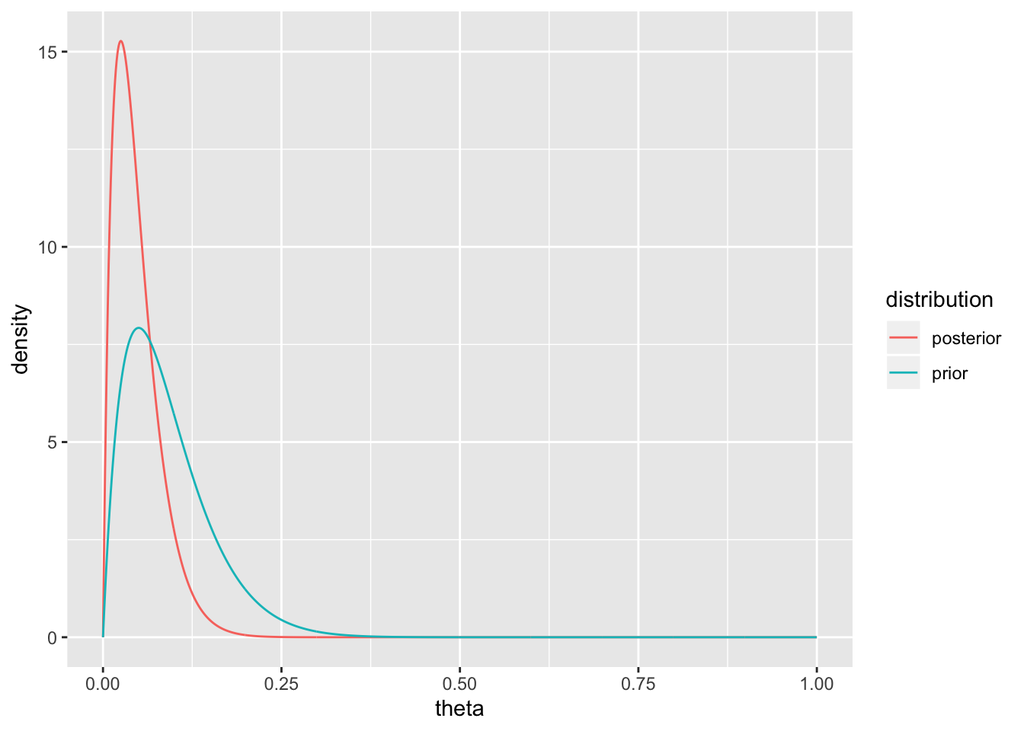

Prior and posterior distributions on theta after observing 0/20 infected individuals. Note the posterior is more tightly peaked around near-zero values.

```r
d = data.frame(
  theta = seq(0, 1, by = 0.001),
  distribution = rep(c("prior", "posterior"), each = 1001),
  density = c(dbeta(seq(0, 1, by = 0.001), 2, 20), dbeta(seq(0, 1, by = 0.001), 2, 40))
)
ggplot(d, aes(x = theta, y = density, color = distribution)) +
  geom_line()
```

Notice that Bayesian and frequentist approaches to parameter estimation differ:

$$\begin{align}
\theta_{ML} &= \underset{\theta}{\text{argmax}} \; P(Y = 0 \mid \theta) = 0 \\
\theta_{MAP} &= \underset{\theta}{\text{argmax}} \; P(\theta \mid Y = 0) = \text{Mode}(\theta \mid Y = 0) = 0.025
\end{align}$$

but also notice that the point estimate is NOT equal to the expectation of $\theta$, since $\mathbb{E}(\theta \mid Y = 0) = 0.048$. We will probably later determine when to use the expectation over the mode.

Finally, notice that we can do very intuitive statistical tests (e.g $P(\theta < 0.10 \mid Y = 0)$) by measuring the areas under our posterior distribution.

## Sensitivity analysis

To quantify how changes in the prior beliefs affect our posterior estimates, we’ll do some calculations. Recall the expectation and variance of Beta distributions. If $X \sim \text{Beta}(\alpha, \beta)$, then

$$\begin{align}
\mathbb{E}(X) &= \frac{\alpha}{\alpha + \beta} \\
\text{Var}(X) &= \frac{\alpha \beta}{(\alpha + \beta)^2 (\alpha + \beta + 1)}.
\end{align}$$

Due to the properties of these functions we can parameterize the Beta distribution alternatively with

- Expectation: $\theta_0 = \frac{\alpha}{\alpha + \beta}$
- Precision: $w = a + b$

Since $(\theta \mid Y = y) \sim \text{Beta}(a + y, b + n - y)$,

$$\begin{align}
\mathbb{E}(\theta \mid Y = y) &= \frac{a + y}{a + b + n} \\
&= \frac{n}{w + n}\frac{y}{n} + \frac{w}{w + n}\theta_0.
\end{align}$$

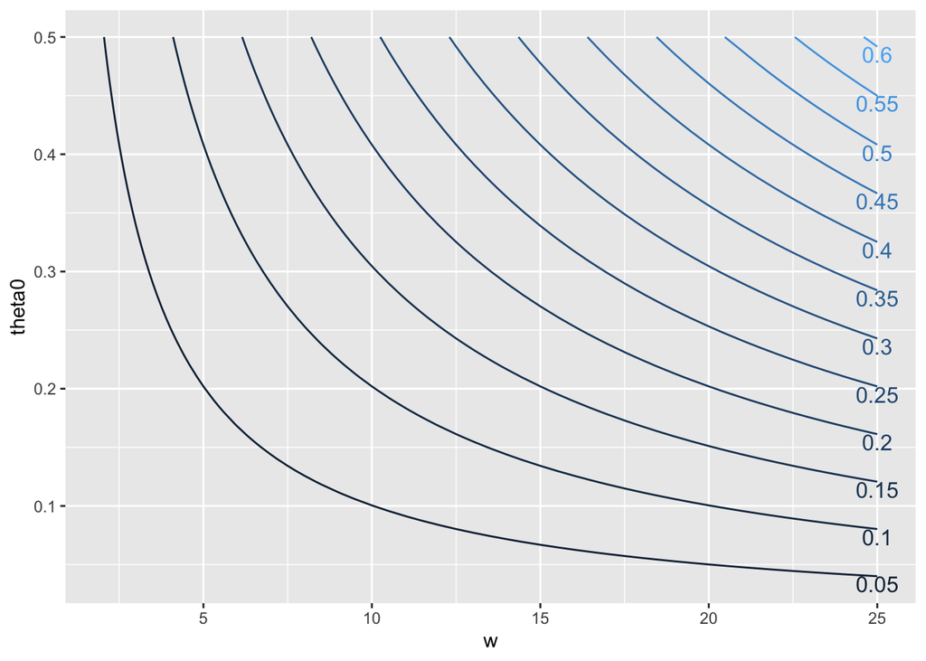

```r
# What is the expected value of theta after observing result y, given a Beta
# prior parameterized by theta0 and w?
N = 20
exp.posterior = function(w, theta0, y) {
  (N / (w + N)) * (y / N) + (w / (w + N)) * theta0
}
Theta0 = rev(seq(0.0, 0.5, by = 0.01))
W = seq(0, 25, by = 0.5)
d = outer(Theta0, W, FUN = function(w, theta0) exp.posterior(w, theta0, 0))
rownames(d) = Theta0
colnames(d) = W

df = melt(d)
colnames(df) = c('theta0', 'w', 'theta')

p = ggplot(df, aes(x = w, y = theta0, z = theta)) +
  geom_contour(aes(colour = ..level..))
library(directlabels)
direct.label(p, method = 'bottom.pieces')
```

## Comparison to non-Bayesian methods

When we use the frequentist maximum likelihood estimator, we get an estimated $\theta_{ML} = 0$. Since our estimate is subject to sampling error, we commonly construct confidence intervals for these estimates.

The previous Bayesian estimate, however, works well for both small and large n. With small $n$, the estimator allows us to encode prior beliefs about the true proportion. With $w$ and $\theta_0$ as before:

$$\hat{\theta} = \mathbb{E}(\theta \mid Y = y) = \frac{n}{n + w}\frac{y}{n} + \frac{w}{n + w}\theta_0.$$

Notice that this is kind of an average between the prior expectation $\theta_0$ and the observed proportion of the data $\frac{y}{n}$, weighted by the amount of data $n$. For large $n$, $\hat{\theta}$ becomes dominated by the data, regardless of prior estimate and confidence.

Theoretical details on the properties of Bayesian estimators are covered later in Section 5.4.

# Example 2: Building a predictive model

A brief synopsis of an example in Chapter 9, where we want to build a predictive model of diabeates progression from 64 variables such as age, sex and BMI.

We use a linear regression model, where $Y_i$ is the disease progression of subject $i$, $\mathbf{x}_i = (x_{i, 1}, \dots, x_{i, 64})$ is a 64-dimensional vector. With unknown coefficient $\beta_i$ and the error term $\sigma$, there are 65 unknown parameters.

$$Y_i = \beta_1 x_{i, 1} + \beta_2 x_{i, 2} + \dots + \beta_{64} x_{i, 64} + \sigma \epsilon_i$$

We define a sparse prior probability distribution, that most coefficients are equal to 0. (Spike and slab models?). This allows us to conduct a Bayesian form of **feature selection** where we evaluate the probability that a specific $\beta_i \neq 0$ given the data $\mathbf{y} = (y_1, \dots, y_{342})$ and predictors $\mathbf{X} = (\mathbf{x}_1, \dots, \mathbf{x}_342)$.

## Bayesian regression does better than standard linear regression

The standard ordinary least squares (OLS) estimate of $\mathbf{\beta}$ does worse than the Bayesian method on the test set. This is due to overfitting, and OLS’s “inability to recognize when the sample size is too small to accurately estimate the regression coefficients.” Sparse linear regression models are key here, and the Bayesian sparsity prior performs well; the common lasso technique introduced by [Tibshirani (1996)](http://www.jstor.org/stable/2346178) is also popular, but this in fact corresponds to Bayesian methods for a special case.

# Next steps

- Chapter 2: probability
- Chapters 3, 4: One-parameter statistical models
- Chapters 5, 6, 7: Bayesian inference with normal models
- Chapters 8, 9, 10, 11, 12: Inference in more complicated statistical methods